# Lab Assignment

You will be analyzing and visualizing data to uncover patterns in theft activity. Your findings and visual insights will provide crucial information that can help allocate resources more effectively and develop strategies to combat bike thefts, ensuring a safer city for all cyclists.

## The Data

[output not shown]

This dataset provides a comprehensive view of bike thefts, including when and where they occur, the financial impact, and other spatial and temporal factors. By analyzing this data, you can gain valuable insights into patterns and trends, which can inform strategies to mitigate bike thefts and enhance urban planning.

Read the data set:

```r
## Load tidyverse package
library(tidyverse)

## Read `bike_data`
thefts <- read_csv("bicycle.csv")

## Take a glance of the `bike_data`
head(thefts)
```

| date | quarter | day_of_week | neighborhood | bike_cost | location | long | lat |
| --- | --- | --- | --- | --- | --- | --- | --- |
| 1/1/2014 | 1/1/2014 | Wednesday | Waterfront Communities-The Island (77) | 1019 | Residential Structures | -79.37720 | 43.63388 |
| 3/1/2014 | 1/1/2014 | Friday | Humewood-Cedarvale (106) | 560 | Residential Structures | -79.42768 | 43.69137 |
| 4/1/2014 | 1/1/2014 | Saturday | Church-Yonge Corridor (75) | 200 | Residential Structures | -79.37902 | 43.65965 |
| 4/1/2014 | 1/1/2014 | Saturday | Leaside-Bennington (56) | 900 | Residential Structures | -79.36607 | 43.70380 |
| 7/1/2014 | 1/1/2014 | Tuesday | South Riverdale (70) | 150 | Residential Structures | -79.33565 | 43.64929 |
| 8/1/2014 | 1/1/2014 | Wednesday | Moss Park (73) | 479 | Residential Structures | -79.36730 | 43.65652 |

Visualize the location of bicycle theft:

```r
library(spatstat)
library(sf)

x <- thefts$long
y <- thefts$lat
win <- owin(xrange = c(min(x), max(x)), yrange = c(min(y), max(y)))
X <- ppp(x = x, y = y, window = win)
plot(X)
axis(1)
```

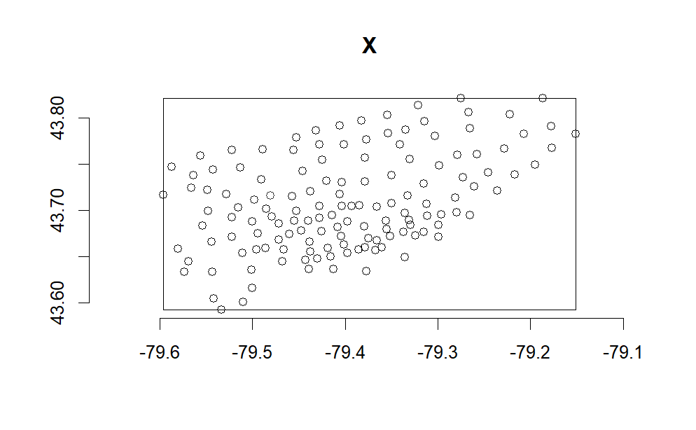

```r
axis(2)
```